# La Bohème

## Handlung

ERSTES BILD  
*Heiligabend in einer Pariser Mansarde*  
Dem Dichter Rodolfo und dem Maler Marcello will die Arbeit nicht von der Hand gehen. Es ist kalt in ihrer Mansarde. Rodolfo opfert großzügig sein neuestes Drama für ein kurzes Feuer im Ofen. Ihr Freund Colline, ein Philosoph, stößt zu ihnen. Gerade hat er vergebens versucht, am Heiligabend seine Bücher im Pfandleihhaus zu Geld zu machen. Kurz darauf folgt der Musiker Schaunard. Er bringt zur allgemeinen Überraschung Essen, Wein, Holz und Geld mit, das er durch einen seltsamen Auftrag verdient hat: Für einen spleenigen Engländer musste er einen Papagei zu Tode musizieren. Das Geld liegt noch auf dem Tisch, als Benoît, der Vermieter, unverhofft vorbeikommt, um die überfällige Miete zu kassieren. Die vier Künstler machen ihn betrunken und verstehen es, ihn unverrichteter Dinge wieder loszuwerden.  
Sie beschließen, den Weihnachtsabend im Café Momus zu verbringen. Rodolfo bleibt zurück, um noch einen Zeitungsartikel zu Ende zu schreiben. Da klopft es: Mimì, eine Nachbarin, bittet um Feuer für ihre erloschene Kerze. Sie verliert ihren Schlüssel, den beide im Dunkeln suchen. Rodolfo sorgt dafür, dass sie ihn nicht zu schnell finden.  
Sie kommen sich näher und verlieben sich ineinander. Als die Freunde von unten nach Rodolfo rufen, zieht das neue Paar mit ihnen ins Momus.

ZWEITES BILD  
*Café Momus*  
Ausgelassener Weihnachtstrubel im Quartier Latin. Straßenhändler bieten ihre Waren an, der Spielzeugverkäufer Parpignol kann sich vor dem Ansturm der Kinder kaum retten. Die vier Bohémiens bringen ihr Geld unter die Leute; Rodolfo kauft ein Häubchen für Mimì. Man trifft sich schließlich zum Essen im Momus, wohin es auch Musetta, Marcellos frühere Geliebte, mit ihrem neuen, reichen Verehrer, Alcindoro, zieht. Marcello ist eifersüchtig, Musetta provoziert ihn und schickt Alcindoro mit einem Auftrag davon, um wieder zu Marcello zurückzukehren. Die beiden Paare, Colline und Schaunard ziehen gutgelaunt von dannen. Alcindoro wird bei seiner Rückkehr die Rechnung für alle begleichen müssen.

DRITTES BILD  
*Februarmorgen am Stadtrand*  
Marcello arbeitet als »Kneipenmaler« in einem Cabaret am Stadtrand, wo auch Musetta als Sängerin auftritt. Mimì will mit ihm über Rodolfos unbegründete Eifersucht sprechen. Marcello rät ihr zur Trennung. Als Rodolfo hinzukommt, versteckt sie sich und hört Rodolfos wahre Beweggründe: Er fühlt sich nicht in der Lage, die schwerkranke Mimì zu versorgen. Mimì verlässt ihr Versteck. Rodolfo und sie wollen nun noch bis zum Ende des Winters zusammen bleiben. Nach einer heftigen Eifersuchtsszene verlässt Musetta Marcello.

VIERTES BILD  
*In der Mansarde* – *ein halbes Jahr später*  
Marcello und Rodolfo gelingt es nicht, ihrer Arbeit nachzugehen. Wenn sie es sich gegenseitig auch nicht eingestehen wollen, sind ihre Gedanken doch bei Musetta und Mimì, die sie seit langem nicht mehr gesehen haben. Colline und Schaunard bringen diesmal nur ein karges Abendessen mit. Die vier Freunde versuchen mit Humor das Beste aus der Situation zu machen.  
Musetta bringt die todkranke Mimì zu ihnen, die Rodolfo noch einmal wiedersehen will. Musetta versetzt ihre Ohrringe, Colline seinen geliebten Mantel, um Medikamente und einen Arzt zu besorgen und der Sterbenden einen letzten Wunsch zu erfüllen. Allein zurückgeblieben erinnern sich Rodolfo und Mimì ihrer ersten Begegnung. Die Freunde kehren zurück. Mimì stirbt. Rodolfo wird es als Letzter gewahr.

## Programmbuch

[Download](https://www.staatsoper-berlin.de/downloads-b/de/produktion/24/programmbuch/4df4bc95c378dee3143b3450ae9a4679/La_boheme_Programmheft_2001_Aufl2_2021.pdf)

## Mehr erfahren

### Hinter den Kulissen: der Kinderchor der Staatsoper bei »La Bohème«

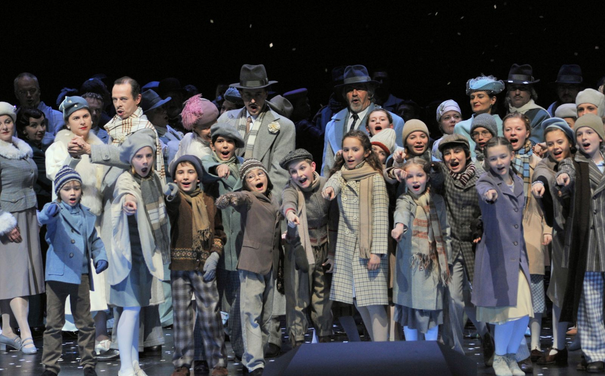

- Wie die »Großen« steht der Kinderchor der Staatsoper auf der großen Bühne. Adéle und Elisabeth haben uns bei der letzten Vorstellung mitgenommen und zeigen uns ihre Welt hinter der Bühne.